# Praca domowa 1

```python
import torch
import torchvision
import numpy as np
import pandas as pd
import matplotlib.pyplot as plt
from sklearn.datasets import load_iris
import tqdm
```

Funkcja trenująca sieci, z możliwością doboru zbioru danych. Będzie wykorzystywana zarówno dla zbioru XOR jak i iris.

```python
def train(net, data_train, data_test, fig = None, learning_rate = 0.03, num_iter = 100, batch_size = 4):
    dataloader_train = torch.utils.data.DataLoader(data_train, batch_size=batch_size,num_workers=1)
    dataloader_test = torch.utils.data.DataLoader(data_test, batch_size=batch_size,num_workers=1)

    loss = torch.nn.CrossEntropyLoss(reduction='none')
    optimizer = torch.optim.SGD(net.parameters(), lr=learning_rate)

    losses = []
    errors_train = []
    errors_test = []

    for epoch in range(num_iter):
        losses_iter = []
        errors_train_iter = []
        errors_test_iter = []

        for data in dataloader_test:
            X, y = data[:,0:-1].float(),data[:,-1].long()
            y_hat = net(X)
            errors_test_iter += [(y != y_hat.argmax(1)).float().mean().item()]

        for data in dataloader_train:
            X, y = data[:,0:-1].float(),data[:,-1].long()
            y_hat = net(X)
            errors_train_iter += [(y != y_hat.argmax(1)).float().mean().item()]
            l = loss(y_hat, y)
            optimizer.zero_grad()
            l.mean().backward()
            losses_iter += [l.mean().item()]
            optimizer.step()

        errors_train += [np.mean(errors_train_iter)]
        errors_test += [np.mean(errors_test_iter)]
        losses += [np.mean(losses_iter)]

    if fig != None:
      fig.plot(range(num_iter), errors_train)
      fig.plot(range(num_iter), errors_test)
      fig.plot(range(num_iter), losses)
      fig.legend(['Error_train', 'Error_test', 'Loss'])

    return errors_train, errors_test
```

```python
def generateNetwork(input, output, layers):
    if len(layers) == 0:
      return torch.nn.Sequential(
        torch.nn.Linear(input, output),
        torch.nn.Softmax(dim=1)
      )



    modules = [torch.nn.Linear(input, layers[0])]
    for l in range(len(layers)-1):
      modules.append(torch.nn.ReLU())
      modules.append(torch.nn.Linear(layers[l], layers[l+1]))
    modules.append(torch.nn.ReLU())
    modules.append(torch.nn.Linear(layers[-1], output))
    modules.append(torch.nn.Softmax(dim=1))

    return torch.nn.Sequential(*modules)
```

## Zbiór XOR

Generacja zbioru oraz podział na testowy i treningowy (w proporcjach 80:20)

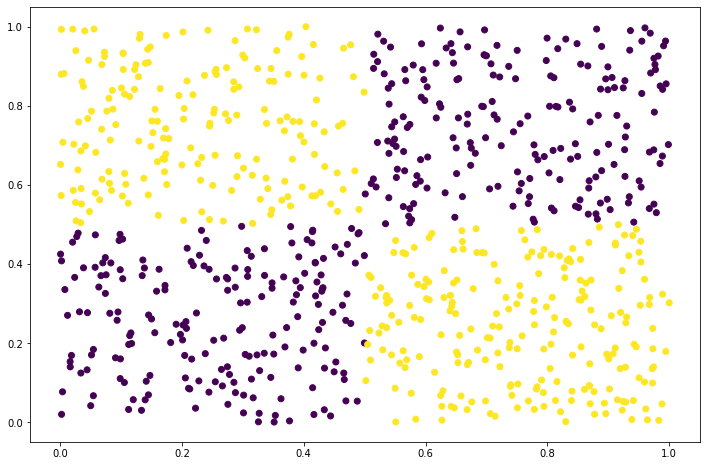

```python
xor_x = np.random.random(1600).reshape(800, 2)
xor_y = (((xor_x[:,0]>0.5)*1+(xor_x[:,1]>0.5)*1)%2).astype(int)

xor_full = pd.DataFrame(np.hstack((xor_x,xor_y[:,None])))
xor_full.iloc[:,2] = xor_full.iloc[:,2].astype('int')
xor_full = xor_full.sample(frac=1).reset_index(drop=True)

split = round(0.8*xor_x.shape[0])
xor_train, xor_test = np.array(xor_full.iloc[:split,:]), np.array(xor_full.iloc[split:,:])

plt.figure(figsize=(12, 8))
plt.scatter(xor_x[:,0],xor_x[:,1],c=xor_y)
plt.show()
```

## Zbiór iris

```python
iris = load_iris()
iris_full = pd.DataFrame(data= np.c_[iris['data'], iris['target']],
                     columns= iris['feature_names'] + ['target'])

iris_full.iloc[:,4] = iris_full.iloc[:,4].astype('int')
iris_full = iris_full.sample(frac=1).reset_index(drop=True)

split = round(0.8*iris_full.shape[0])
iris_train, iris_test = np.array(iris_full.iloc[:split,:]), np.array(iris_full.iloc[split:,:])

iris_full.head()
```

|  | sepal length (cm) | sepal width (cm) | petal length (cm) | petal width (cm) | target |
| --- | --- | --- | --- | --- | --- |
| 0 | 5.1 | 2.5 | 3.0 | 1.1 | 1 |
| 1 | 4.6 | 3.6 | 1.0 | 0.2 | 0 |
| 2 | 5.5 | 2.3 | 4.0 | 1.3 | 1 |
| 3 | 5.1 | 3.5 | 1.4 | 0.2 | 0 |
| 4 | 5.1 | 3.4 | 1.5 | 0.2 | 0 |

## Porównanie architektur sieci na zbiorze XOR

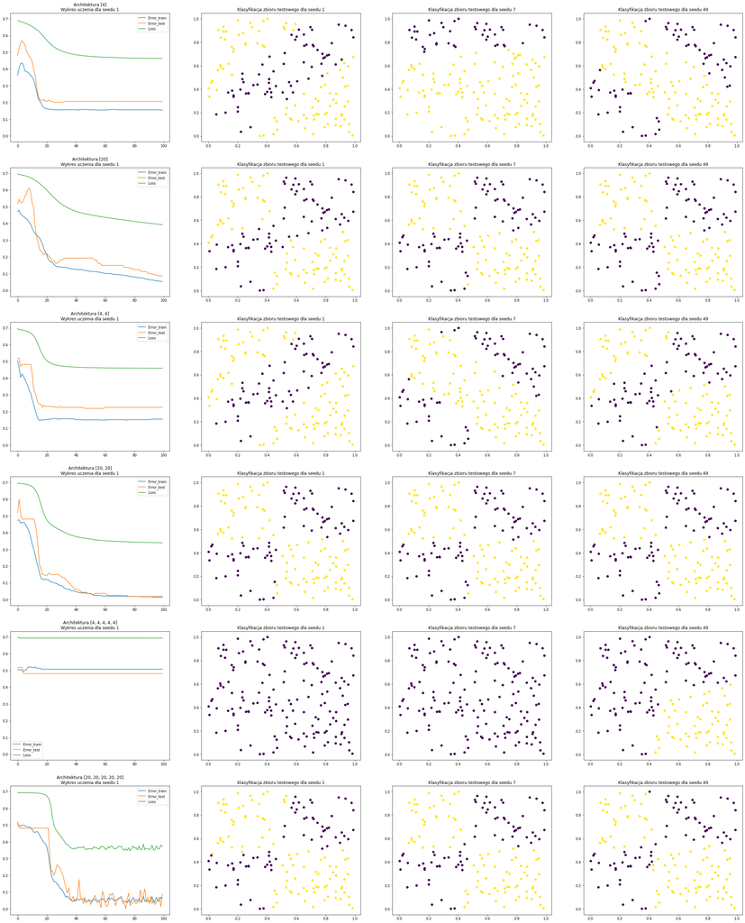

```python
def netComparison(data_train, data_test, networks):
    fig, axes = plt.subplots(len(networks), 4, figsize=(38, 8*len(networks)), sharey='col')
    for i in tqdm.tqdm(range(len(networks))):
      netRecipe = networks[i]
      for s in range(3):
        seed = 7**s
        torch.manual_seed(seed)
        np.random.seed(seed)

        net = generateNetwork(2, 2, netRecipe)
        if s == 0:
          train(net, data_train, data_test, axes[i,0])
          axes[i,0].set_title("Architektura "+str(netRecipe)+"\nWykres uczenia dla seedu "+str(seed))
        else:
          train(net, data_train, data_test)

        parsed_test = net(torch.Tensor(data_test[:,:-1]).float()).detach().numpy()[:,1]
        axes[i,s+1].scatter(data_test[:,0], data_test[:,1], c=parsed_test>0.5)
        axes[i,s+1].set_title("Klasyfikacja zbioru testowego dla seedu "+str(seed))
    plt.show()

netComparison(xor_train, xor_test, [
    [4],
    [20],
    [4, 4],
    [20, 20],
    [4, 4, 4, 4, 4],
    [20, 20, 20, 20, 20],
])
```

To co widać od razu to to, że pomimo zbiór XOR jest dosyć prostym problemem, to zarówno jedna warstwa z 4 neuronami, jak i dwie warstwy z 4 neuronami nie dała sobie z nim rady. W tym przypadku, poza dużym błędem, widać bardzo dużą zmienność granic decyzyjnych przy kolejnych treningach sieci.

Zarówno dla modelu z jedną warstwą 20 neuronową, jak i dwiema warstwami 20 neuronowymi wyniki są już zdecydowanie lepsze, a zmienność między treningami znacznie mniejsza. Można także zauważyć niewielką przewagę modelu dwuwarstwowego nad jednowarstwowym.

Najciekawsze jednak okazują się modele o pięciu warstwach. W przypadku 4 neuronów sieć była zupełnie nieprzydatna, do takiego stopnia że klasyfikuje wszystkie punkty tą samą klasą. Ten model okazuje się nawet gorszy niż tylko jedna, 4 neuronowa warstwa. Tak samo sieć z pięcioma warstwami, z 20 neuronami każda, jest gorsza niż dwie warstwy 20 neuronowe, jednak różnica nie aż tak widoczna. Natomiast bardzo poszarpany wykres nauki sieci świadczy o dużych problemach z dalszym treningiem.

### Porównanie learning rate na zbiorze iris i analiza zjawiska przeuczenia

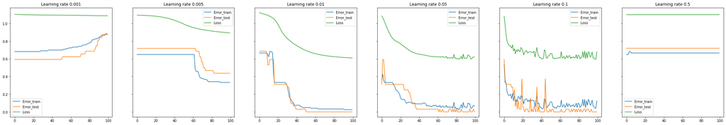

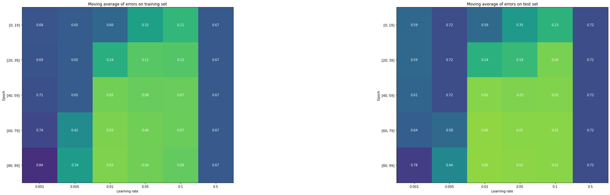

```python
def learningRateComparison(data_train, data_test, rates):
    fig, axes = plt.subplots(1, len(rates), figsize=(38, 6), sharey=True)
    map_train = []
    map_test = []
    display_epochs = []
    tick_size = 20
    for i in tqdm.tqdm(range(len(rates))):
      net = generateNetwork(4, 3, [5, 5])
      loss_train, loss_test = train(net, data_train, data_test, axes[i], rates[i])
      if len(display_epochs) == 0:
        display_epochs = ["["+str(i*tick_size)+"; "+str((i+1)*tick_size-1)+"]" for i in range(len(loss_train)//tick_size)]
      map_train.append([np.mean(loss_train[(i*tick_size):((i+1)*tick_size-1)]) for i in range(len(loss_train)//tick_size)])
      map_test.append([np.mean(loss_test[(i*tick_size):((i+1)*tick_size-1)]) for i in range(len(loss_test)//tick_size)])
      axes[i].set_title("Learning rate "+str(rates[i]))


    fig, (axis_train, axis_test) = plt.subplots(1, 2, figsize=(38, 10))


    vmin=np.min([map_train,map_test])
    axis_train.imshow(1-np.transpose(map_train, (1, 0)), vmin=vmin, vmax=1.2)
    axis_test.imshow(1-np.transpose(map_test, (1, 0)), vmin=vmin, vmax=1.2)

    # Podpisy na heatmapie treningowej
    axis_train.set_title("Moving average of errors on training set")
    axis_train.set_xlabel("Learning rate")
    axis_train.set_xticks(np.arange(len(rates)))
    axis_train.set_xticklabels(rates)
    axis_train.set_ylabel("Epoch")
    axis_train.set_yticks(np.arange(len(display_epochs)))
    axis_train.set_yticklabels(display_epochs)

    # Podpisy na heatmapie testowej
    axis_test.set_title("Moving average of errors on test set")
    axis_test.set_xlabel("Learning rate")
    axis_test.set_xticks(np.arange(len(rates)))
    axis_test.set_xticklabels(rates)
    axis_test.set_ylabel("Epoch")
    axis_test.set_yticks(np.arange(len(display_epochs)))
    axis_test.set_yticklabels(display_epochs)

    for i in range(len(display_epochs)):
      for j in range(len(rates)):
          text = axis_train.text(j, i, "{:.2f}".format(map_train[j][i]), ha="center", va="center", color="w")
          text = axis_test.text(j, i, "{:.2f}".format(map_test[j][i]), ha="center", va="center", color="w")

    plt.show()

torch.manual_seed(7)
learningRateComparison(iris_train, iris_test, [0.001, 0.005, 0.01, 0.05, 0.1, 0.5])
```

To co jest najbardziej zaskakujące w tej analizie to uzyskany wykres dla najmniejszego learning rate - przez dłuższy czas nic się nie zmienia, aż w pewnym momencie zaczyna dochodzić do pogarszania się sieci. Jest to zachowanie bardzo nietypowe, które wymagałoby głębszej analizy.

W przypadku kolejnych czterech learning rate zachowanie jest takie, jakie można się było spodziewać. Dla wszystkich trzech parametrów sieć zbiega, a wraz ze większaniem learning rate spada ilość potrzebnych epok aby uzyskać satysfakcjonujący wynik. Mimo tego, po stu epokach najlepszy wynik uzyskuje już learning rate 0.01, a nie największy jakby można było zgadywać. Ponadto, im większy jest learning rate tym bardziej poszarpany jest wykres uczenia - nie jest to pożądane zachowanie, które może powodować dalsze problemy.

Dla największego learning rate sytuacja jest już zupełnie inna - sieć całkowicie przestała się uczyć.

Na powyższych wykresach widać także inną, bardzo ciekawą zależność - różnice w wynikach na zbiorze testowym i treningowym.

W przypadku najmniejszego i największego learning rate, nie wprowadzają one żadnych dodatkowych informacji, ponieważ są jedynie zależne od losowego wygenerowania wag początkowych.

Dla learning rate 0.005 wykres wygląda dosyć standardowo - błąd na zbiorze testowym jest większy niż na zbiorze treningowym. Przez wszystkie epoki błąd na zbiorze testowym maleje - nie mamy zatem do czynienia ze zjawiskiem przeuczenia.

Dla learning rate 0.01, 0.05 i 0.1 sytuacja jest już znacznie ciekawsza - po paru wstępnych epokach wynik na zbiorze testowym jest lepszy, niż na zbiorze treningowym. Może to świadczyć o bardzo dobrej umiejętności generalizacji przez sieć, lub do niepoprawnego podziału zbioru danych. Pomimo mocnego poszarpania wykresów, nie można powiedzieć że doszło do przeuczenia.

### Wnioski

Jak widać z przedstawionych analiz, zarówno struktura sieci jak i learning rate (oraz, generalizując, inne hiperparametry) muszą być dokładnie dobierane specjalnie dla rozwiązywanego problemu. Za równo zbyt małe, jak i zbyt duże wartości będą powodować niską jakość modelu. W przypadku wybraniu hiperparametrów dalekich od optymalnych nawet znaczące zwiększenie liczby epok treningu nie poprawi naszych rezultatów.